# Group1_data exploration and prediction

```python
import pandas as pd
import numpy as np
import statsmodels.formula.api as smf
import matplotlib.pyplot as plt
from sklearn.preprocessing import LabelEncoder
from sklearn.metrics import roc_auc_score
from sklearn.model_selection import train_test_split
from sklearn.model_selection import KFold
from sklearn.preprocessing import PolynomialFeatures
from sklearn.linear_model import LogisticRegression
from sklearn.linear_model import LinearRegression
from sklearn.preprocessing import StandardScaler
from sklearn.linear_model import Lasso
from sklearn.linear_model import Ridge
from sklearn.tree import DecisionTreeRegressor, plot_tree
from sklearn.tree import plot_tree
from sklearn.ensemble import RandomForestClassifier
from sklearn.ensemble import RandomForestRegressor
from sklearn.metrics import roc_auc_score
from sklearn.metrics import confusion_matrix
from  sklearn.ensemble import GradientBoostingClassifier
from sklearn.ensemble import GradientBoostingRegressor
from sklearn.model_selection import GridSearchCV
from sklearn.metrics import mean_absolute_error, mean_squared_error, r2_score
from sklearn.inspection import PartialDependenceDisplay
import shap
from sklearn.ensemble import GradientBoostingRegressor
from sklearn.model_selection import RandomizedSearchCV
import lightgbm as lgb
from sklearn.preprocessing import StandardScaler
from sklearn.preprocessing import OneHotEncoder
from sklearn.compose import ColumnTransformer
from sklearn.pipeline import Pipeline
from sklearn.preprocessing import MinMaxScaler
from tensorflow.keras.models import load_model
import seaborn as sns
```

```python
df_train = pd.read_csv("Data-train.csv", index_col= 0)
df_train.drop(["productID","brandID"], axis = 1 ,inplace=True)
df_train.head()
```

|  | attribute1 | attribute2 | attribute3 | attribute4 | clickVolume | avgOriginalUnitPrice | avgFinalUnitPrice | ma14SalesVolume | weekday | meanAge | gender | meanEducation | maritalStatus | plus | meanPurchasePower | meanUserLevel | meanCityLevel | sales |
| --- | --- | --- | --- | --- | --- | --- | --- | --- | --- | --- | --- | --- | --- | --- | --- | --- | --- | --- |
| 0 | 3.0 | 100.0 | 2 | 14.015189 | 9909.0 | 297.385572 | 205.815006 | 655.000000 | 7 | 31.521395 | 0.212009 | 3.160951 | 0.621749 | 0.263966 | 2.206178 | 2.769983 | 1.982895 | 227 |
| 1 | 3.0 | 60.0 | 2 | 3.540835 | 147.0 | 288.881638 | 290.166069 | 3.357143 | 2 | 29.594697 | 0.165580 | 3.396271 | 0.514384 | 0.498430 | 1.927908 | 3.688905 | 3.587507 | 4 |
| 2 | 3.0 | 40.0 | 1 | 6.920011 | 340.0 | 80.650174 | 57.015822 | 2.428571 | 6 | 27.571841 | 0.110140 | 2.969748 | 0.455610 | 0.021698 | 2.039529 | 1.757368 | 1.465526 | 4 |
| 3 | 1.0 | 60.0 | 4 | 14.552424 | 510.0 | 53.936075 | 37.789425 | 23.142857 | 1 | 30.348968 | 0.282176 | 2.908912 | 0.317343 | 0.286305 | 2.302469 | 3.039906 | 2.400244 | 36 |
| 4 | 3.0 | 60.0 | 10 | 9.571562 | 869.0 | 79.595617 | 68.988354 | 69.785714 | 4 | 30.750593 | 0.332925 | 2.925823 | 0.669849 | 0.209709 | 2.186458 | 2.484153 | 2.529079 | 31 |

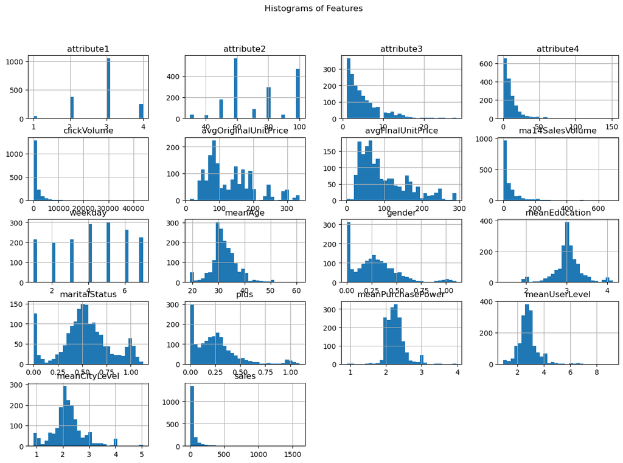

```python
df_train.hist(bins=30, figsize=(15, 10))
plt.suptitle("Histograms of Features")
plt.show()
```

attribute1, attribute2 and weekday are identified as catagorical variables

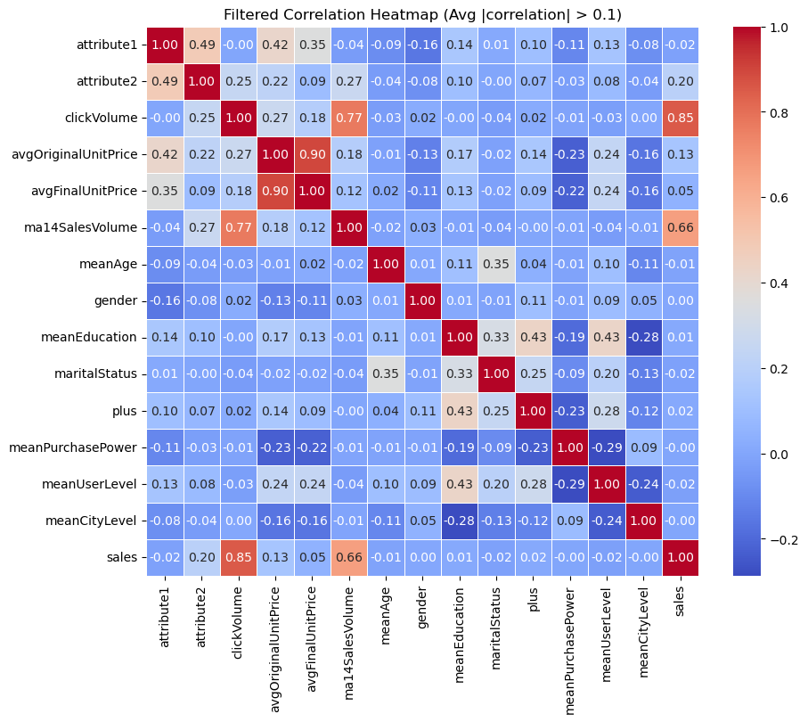

```
Index(['attribute1', 'attribute2', 'clickVolume', 'avgOriginalUnitPrice',
       'avgFinalUnitPrice', 'ma14SalesVolume', 'meanAge', 'gender',
       'meanEducation', 'maritalStatus', 'plus', 'meanPurchasePower',
       'meanUserLevel', 'meanCityLevel', 'sales'],
      dtype='object')
```

```python
corr_matrix = df_train.corr()
avg_corr = corr_matrix.abs().mean()

filtered_columns = avg_corr[avg_corr > 0.1].index
filtered_corr = corr_matrix.loc[filtered_columns, filtered_columns]

# Plot the filtered heatmap
plt.figure(figsize=(10, 8))
sns.heatmap(filtered_corr, annot=True, cmap='coolwarm', fmt=".2f", linewidths=0.5)
plt.title('Filtered Correlation Heatmap (Avg |correlation| > 0.1)')
plt.show()
print(filtered_columns)
```

Features with average corr > 0.1 are selected

```python
df_train = df_train[filtered_columns]

categorical_columns = ['attribute1', 'attribute2' ]
continuous_columns = [col for col in df_train.columns if col not in categorical_columns]
df_train = pd.get_dummies(df_train, columns=categorical_columns, drop_first=True)
df_train = pd.DataFrame(df_train, columns=df_train.columns)

X = df_train.drop(["sales"], axis = 1 ,inplace=False)
y = np.log1p(df_train["sales"] ).values.ravel()
X_train , X_test , y_train , y_test = train_test_split(X, y , train_size= int(0.8*len(df_train)), random_state= 10)
```

### Both GridSearchCV and RandomizedSearchCV for hyperparameter sampling was used to find the best parameter for gradient boosting

```python
param_distributions = {
    'n_estimators': [1000, 500],
    'learning_rate': [ 0.005, 0.01, 0.02],
    'max_depth': [2,4, 6],
    'min_samples_split': [ 0.2, 0.05, 0.1],
    'max_features': ['sqrt', 'log2'],
}
gbr = GradientBoostingRegressor(random_state=10)

# Set up grid search to tune hyperparameters
grid_search = GridSearchCV(gbr, param_distributions, cv=10, scoring='neg_mean_squared_error', random_state = 10)

grid_search.fit(X_train, y_train)
```

[output not shown]

```python
param_distributions = {
    'n_estimators': [1000, 500],
    'learning_rate': [ 0.005, 0.01, 0.02],
    'max_depth': [3, 6],
    'min_samples_split': [ 0.2, 0.05, 0.1],
    'max_features': ['sqrt', 'log2'],
    'subsample': [0.1,  0.5, 0.8]
}
gbr = GradientBoostingRegressor(random_state=10)

# Set up grid search to tune hyperparameters
grid_search = RandomizedSearchCV(gbr, param_distributions, n_iter=100, cv=10, scoring='neg_mean_squared_error', random_state=10)


grid_search.fit(X_train, y_train)
```

```
RandomizedSearchCV(cv=10, estimator=GradientBoostingRegressor(random_state=10),
                   n_iter=100,
                   param_distributions={'learning_rate': [0.005, 0.01, 0.02],
                                        'max_depth': [3, 6],
                                        'max_features': ['sqrt', 'log2'],
                                        'min_samples_split': [0.2, 0.05, 0.1],
                                        'n_estimators': [1000, 500],
                                        'subsample': [0.1, 0.5, 0.8]},
                   random_state=10, scoring='neg_mean_squared_error')
```

The results generated by the grid search and hyperparameter tunning are evaluated using code to identify the best model. The evaluation focuses on selecting the model with lowerest Mean Squared Error (MSE) and the smallest difference between test_mse and train_mse, ensuring minimal overfitting and better generalization.

```python
cv_results = grid_search.cv_results_

# Store results in a DataFrame for easier analysis
results_df = pd.DataFrame({
    'params': cv_results['params'],
    'mean_test_score': -cv_results['mean_test_score'],  # Convert to positive MSE
    'std_test_score': cv_results['std_test_score']
})

# Initialize variables to track the best model considering both MSE and overfitting
best_model = None
best_params = None
smallest_overfitting = float('inf')
best_mse = float('inf')

# Iterate through all the parameter combinations
for index, row in results_df.iterrows():
    model = GradientBoostingRegressor(**row['params'], random_state=4211)
    model.fit(X_train, y_train)

    # Calculate MSE for training and validation sets
    train_mse = mean_squared_error(y_train, model.predict(X_train))
    test_mse = mean_squared_error(y_test, model.predict(X_test))

    # Calculate MSE difference
    mse_difference = test_mse - train_mse

    # Consider both the validation MSE and overfitting (MSE difference)
    if test_mse + 0.5*mse_difference < 0.5*smallest_overfitting + best_mse:
        best_model = model
        best_params = row['params']
        best_mse = test_mse
        smallest_overfitting = mse_difference

# Print the best parameters, MSE, and overfitting metric
print("Best parameters:", best_params)
print("Best Validation MSE:", best_mse)
print("MSE Difference (Validation - Training):", smallest_overfitting)
```

[output not shown]

## Testing of various outcome of parameters from gridsearch and hyperparameter tuning by different approach of gridsearch setting

```python
df_train = pd.read_csv("Data-train.csv", index_col= 0)
```

```python
df_train.drop(["productID","brandID"], axis = 1 ,inplace=True)
df_train = df_train[filtered_columns]
categorical_columns = ['attribute1', 'attribute2' ]
continuous_columns = [col for col in df_train.columns if col not in categorical_columns]
df_train = pd.get_dummies(df_train, columns=categorical_columns, drop_first=True)
df_train = pd.DataFrame(df_train, columns=df_train.columns)

X = df_train.drop(["sales"], axis = 1 ,inplace=False)
y = np.log1p(df_train["sales"] ).values.ravel()
X_train , X_test , y_train , y_test = train_test_split(X, y , train_size= int(0.8*len(df_train)), random_state= 10)
```

#### Model 1

```python
MSE = np.zeros(100)
mse_diff = np.zeros(100)
ave_mse = 0
ave_mse_diff = 0

for i in range (100):
    X = df_train.drop(["sales"], axis = 1 ,inplace=False)
    y = np.log(df_train["sales"] ).values.ravel()
    X_train , X_test , y_train , y_test = train_test_split(X, y , train_size= int(0.8*len(df_train)), random_state=i)

    gbr = GradientBoostingRegressor(
        n_estimators=1000,
        min_samples_split=0.05,
        max_features='sqrt',
        max_depth=6,
        learning_rate=0.02,
        subsample =  0.8,
        random_state = i
    )

    gbr.fit(X_train, y_train.ravel())
    y_pred = gbr.predict(X_test)
    mse_test = mean_squared_error(y_test, y_pred)
    mse_train = mean_squared_error(y_train, gbr.predict(X_train))
    mse_difference =  mse_test - mse_train
    MSE[i] = mse_test
    mse_diff[i] = mse_difference

ave_mse = np.mean(MSE)
ave_mse_diff = np.mean(mse_diff)

print("Ave Mean Squared Error:", ave_mse)
print("MSE difference:", ave_mse_diff)
print("Bet MSE", np.min(MSE))
```

```
Ave Mean Squared Error: 0.19509279315982472
MSE difference: 0.16741267535236148
Bet MSE 0.14785534296551736
```

Graphs which demonstrade the mse differnent of training set and testing set with regards to the increase in train set size are ploted.

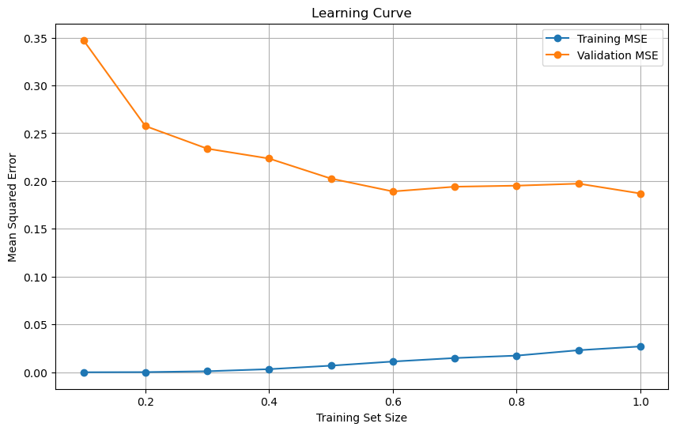

```python
random_state = 10
train_sizes = np.linspace(0.1, 1.0, 10)
train_scores, val_scores = [], []

for train_size in train_sizes:
    X_train_partial = X_train[:int(train_size * len(X_train))]
    y_train_partial = y_train[:int(train_size * len(y_train))]
    gbr.fit(X_train_partial, y_train_partial)
    train_scores.append(mean_squared_error(y_train_partial, gbr.predict(X_train_partial)))
    val_scores.append(mean_squared_error(y_test, gbr.predict(X_test)))

plt.figure(figsize=(10, 6))
plt.plot(train_sizes, train_scores, label='Training MSE', marker='o')
plt.plot(train_sizes, val_scores, label='Validation MSE', marker='o')
plt.xlabel('Training Set Size')
plt.ylabel('Mean Squared Error')
plt.title('Learning Curve')
plt.legend()
plt.grid(True)
plt.show()
```

### Model 2

```python
MSE = np.zeros(100)
mse_diff = np.zeros(100)
ave_mse = 0
ave_mse_diff = 0

for i in range (100):
    X = df_train.drop(["sales"], axis = 1 ,inplace=False)
    y = np.log(df_train["sales"] ).values.ravel()
    X_train , X_test , y_train , y_test = train_test_split(X, y , train_size= int(0.8*len(df_train)), random_state=i)


    gbr = GradientBoostingRegressor(
        n_estimators=1000,
        min_samples_split=0.05,
        max_features='sqrt',
        max_depth=6,
        learning_rate=0.01,
        subsample =  0.5,
        random_state = i
    )

    gbr.fit(X_train, y_train.ravel())
    y_pred = gbr.predict(X_test)
    mse_test = mean_squared_error(y_test, y_pred)
    mse_train = mean_squared_error(y_train, gbr.predict(X_train))
    mse_difference =  mse_test - mse_train
    MSE[i] = mse_test
    mse_diff[i] = mse_difference

ave_mse = np.mean(MSE)
ave_mse_diff = np.mean(mse_diff)

print("Ave Mean Squared Error:", ave_mse)
print("MSE difference:", ave_mse_diff)
print("Bet MSE", np.min(MSE) )
```

```
Ave Mean Squared Error: 0.20512149432416574
MSE difference: 0.12398171374285781
Bet MSE 0.15187445444383746
```

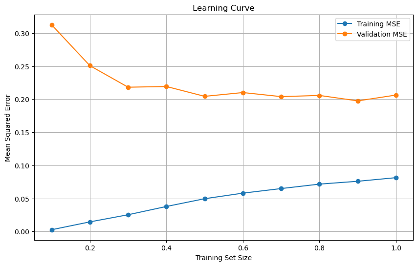

```python
random_state = 10
train_sizes = np.linspace(0.1, 1.0, 10)
train_scores, val_scores = [], []

for train_size in train_sizes:
    X_train_partial = X_train[:int(train_size * len(X_train))]
    y_train_partial = y_train[:int(train_size * len(y_train))]
    gbr.fit(X_train_partial, y_train_partial)
    train_scores.append(mean_squared_error(y_train_partial, gbr.predict(X_train_partial)))
    val_scores.append(mean_squared_error(y_test, gbr.predict(X_test)))

plt.figure(figsize=(10, 6))
plt.plot(train_sizes, train_scores, label='Training MSE', marker='o')
plt.plot(train_sizes, val_scores, label='Validation MSE', marker='o')
plt.xlabel('Training Set Size')
plt.ylabel('Mean Squared Error')
plt.title('Learning Curve')
plt.legend()
plt.grid(True)
plt.show()
```

#### Model 3

```python
MSE = np.zeros(100)
mse_diff = np.zeros(100)
ave_mse = 0
ave_mse_diff = 0

for i in range (100):
    X = df_train.drop(["sales"], axis = 1 ,inplace=False)
    y = np.log(df_train["sales"] ).values.ravel()
    X_train , X_test , y_train , y_test = train_test_split(X, y , train_size= int(0.8*len(df_train)), random_state=i)


    gbr = GradientBoostingRegressor(
        n_estimators=1000,
        min_samples_split=0.1,
        max_features='sqrt',
        max_depth=4,
        learning_rate=0.02,
        subsample =  0.5,
        random_state = i
    )

    gbr.fit(X_train, y_train.ravel())
    y_pred = gbr.predict(X_test)
    mse_test = mean_squared_error(y_test, y_pred)
    mse_train = mean_squared_error(y_train, gbr.predict(X_train))
    mse_difference =  mse_test - mse_train

    MSE[i] = mse_test
    mse_diff[i] = mse_difference

ave_mse = np.mean(MSE)
ave_mse_diff = np.mean(mse_diff)

print("Ave Mean Squared Error:", ave_mse)
print("MSE difference:", ave_mse_diff)
print("Bet MSE", np.min(MSE) )
```

```
Ave Mean Squared Error: 0.21358102890775807
MSE difference: 0.113752240829613
Bet MSE 0.16400929841576092
```

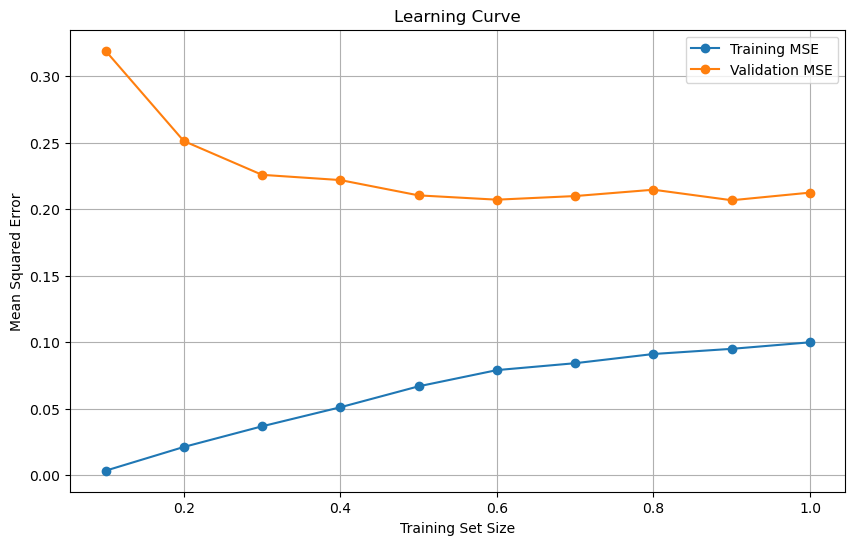

```python
random_state = 10
train_sizes = np.linspace(0.1, 1.0, 10)
train_scores, val_scores = [], []

for train_size in train_sizes:
    X_train_partial = X_train[:int(train_size * len(X_train))]
    y_train_partial = y_train[:int(train_size * len(y_train))]
    gbr.fit(X_train_partial, y_train_partial)
    train_scores.append(mean_squared_error(y_train_partial, gbr.predict(X_train_partial)))
    val_scores.append(mean_squared_error(y_test, gbr.predict(X_test)))

plt.figure(figsize=(10, 6))
plt.plot(train_sizes, train_scores, label='Training MSE', marker='o')
plt.plot(train_sizes, val_scores, label='Validation MSE', marker='o')
plt.xlabel('Training Set Size')
plt.ylabel('Mean Squared Error')
plt.title('Learning Curve')
plt.legend()
plt.grid(True)
plt.show()
```

#### Model 4

```python
MSE = np.zeros(100)
mse_diff = np.zeros(100)
ave_mse = 0
ave_mse_diff = 0

for i in range (100):
    X = df_train.drop(["sales"], axis = 1 ,inplace=False)
    y = np.log(df_train["sales"] ).values.ravel()
    X_train , X_test , y_train , y_test = train_test_split(X, y , train_size= int(0.8*len(df_train)), random_state=i)


    gbr = GradientBoostingRegressor(
    n_estimators=1000,
        min_samples_split=0.05,
        max_features='sqrt',
        max_depth=4,
        learning_rate=0.01,
        random_state = i
    )
    gbr.fit(X_train, y_train.ravel())
    y_pred = gbr.predict(X_test)
    mse_test = mean_squared_error(y_test, y_pred)
    mse_train = mean_squared_error(y_train, gbr.predict(X_train))
    mse_difference =  mse_test - mse_train

    MSE[i] = mse_test
    mse_diff[i] = mse_difference

ave_mse = np.mean(MSE)
ave_mse_diff = np.mean(mse_diff)

print("Ave Mean Squared Error:", ave_mse)
print("MSE difference:", ave_mse_diff)
```

```
Ave Mean Squared Error: 0.2217537960468011
MSE difference: 0.12100732125991115
```

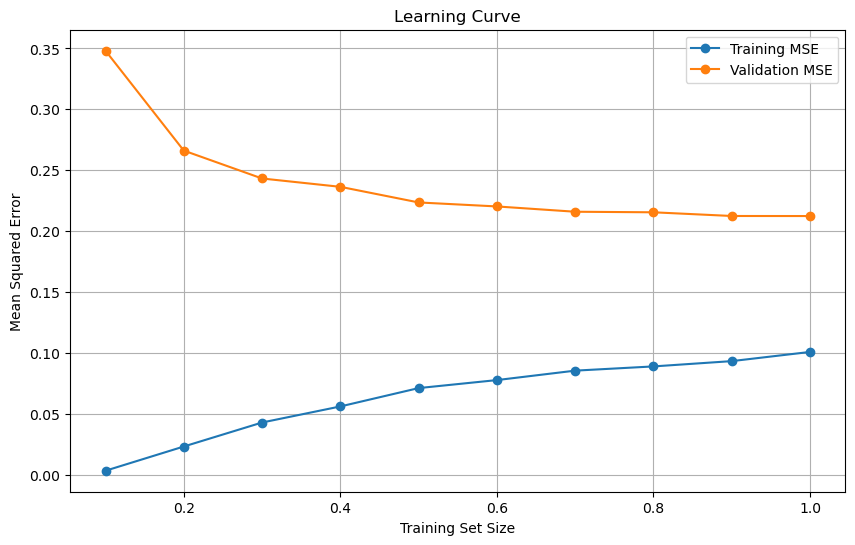

```python
random_state = 10
train_sizes = np.linspace(0.1, 1.0, 10)
train_scores, val_scores = [], []

for train_size in train_sizes:
    X_train_partial = X_train[:int(train_size * len(X_train))]
    y_train_partial = y_train[:int(train_size * len(y_train))]
    gbr.fit(X_train_partial, y_train_partial)
    train_scores.append(mean_squared_error(y_train_partial, gbr.predict(X_train_partial)))
    val_scores.append(mean_squared_error(y_test, gbr.predict(X_test)))

plt.figure(figsize=(10, 6))
plt.plot(train_sizes, train_scores, label='Training MSE', marker='o')
plt.plot(train_sizes, val_scores, label='Validation MSE', marker='o')
plt.xlabel('Training Set Size')
plt.ylabel('Mean Squared Error')
plt.title('Learning Curve')
plt.legend()
plt.grid(True)
plt.show()
```

#### Model 5

```python
MSE = np.zeros(100)
mse_diff = np.zeros(100)
ave_mse = 0
ave_mse_diff = 0

for i in range (100):
    X = df_train.drop(["sales"], axis = 1 ,inplace=False)
    y = np.log(df_train["sales"] ).values.ravel()
    X_train , X_test , y_train , y_test = train_test_split(X, y , train_size= int(0.8*len(df_train)), random_state=i)


    gbr = GradientBoostingRegressor(
    n_estimators=1000,
        min_samples_split=0.05,
        max_features='sqrt',
        max_depth=9,
        learning_rate=0.02,
        subsample = 0.5,
        random_state = i
    )
    gbr.fit(X_train, y_train.ravel())
    y_pred = gbr.predict(X_test)
    mse_test = mean_squared_error(y_test, y_pred)
    mse_train = mean_squared_error(y_train, gbr.predict(X_train))
    mse_difference =  mse_test - mse_train

    MSE[i] = mse_test
    mse_diff[i] = mse_difference

ave_mse = np.mean(MSE)
ave_mse_diff = np.mean(mse_diff)

print("Ave Mean Squared Error:", ave_mse)
print("MSE difference:", ave_mse_diff)
print("Bet MSE", np.min(MSE) )
```

```
Ave Mean Squared Error: 0.19289462209470862
MSE difference: 0.17206045610833684
Bet MSE 0.14731578774547333
```

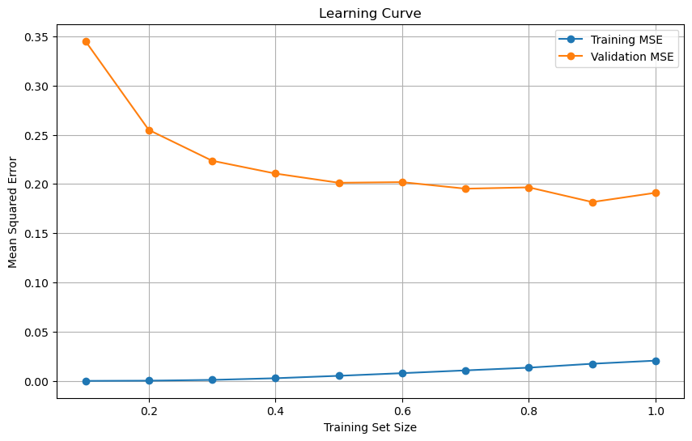

```python
random_state = 10
train_sizes = np.linspace(0.1, 1.0, 10)
train_scores, val_scores = [], []

for train_size in train_sizes:
    X_train_partial = X_train[:int(train_size * len(X_train))]
    y_train_partial = y_train[:int(train_size * len(y_train))]
    gbr.fit(X_train_partial, y_train_partial)
    train_scores.append(mean_squared_error(y_train_partial, gbr.predict(X_train_partial)))
    val_scores.append(mean_squared_error(y_test, gbr.predict(X_test)))

plt.figure(figsize=(10, 6))
plt.plot(train_sizes, train_scores, label='Training MSE', marker='o')
plt.plot(train_sizes, val_scores, label='Validation MSE', marker='o')
plt.xlabel('Training Set Size')
plt.ylabel('Mean Squared Error')
plt.title('Learning Curve')
plt.legend()
plt.grid(True)
plt.show()
```

Average Mean Squared Error across 100 random states: 0.2051

Average MSE Difference(test_mse - train_mse): 0.1240

Best MSE: 0.1519

# Inventory Problem

Repeat steps for feature selection and run the model

```python
df_train = pd.read_csv("Data-train.csv", index_col= 0)
df_train.drop(["productID","brandID"], axis = 1 ,inplace=True)

corr_matrix = df_train.corr()
avg_corr = corr_matrix.abs().mean()
filtered_columns = avg_corr[avg_corr > 0.1].index

df_train = df_train[filtered_columns]
categorical_columns = ['attribute1', 'attribute2' ]
continuous_columns = [col for col in df_train.columns if col not in categorical_columns]
df_train = pd.get_dummies(df_train, columns=categorical_columns, drop_first=True)
df_train = pd.DataFrame(df_train, columns=df_train.columns)

X = df_train.drop(["sales"], axis = 1 ,inplace=False)
y = np.log1p(df_train["sales"] ).values.ravel()
X_train , X_test , y_train , y_test = train_test_split(X, y , train_size= int(0.8*len(df_train)), random_state= 10)
```

```python
    gbr = GradientBoostingRegressor(
        n_estimators=1000,
        min_samples_split=0.05,
        max_features='sqrt',
        max_depth=6,
        learning_rate=0.01,
        subsample =  0.5,
        random_state = 10
    )

gbr.fit(X_train, y_train.ravel())
y_pred = gbr.predict(X_test)
mse_test = mean_squared_error(y_test, y_pred)
mse_train = mean_squared_error(y_train, gbr.predict(X_train))
mse_difference =  mse_test - mse_train
```

To maximize profit, since the difference between the selling price and cost is greater than the difference between cost and salvage value, it is more profitable to stock more inventory than the predicted sales. This approach helps ensure you don't miss potential sales, even if actual demand exceeds the prediction.

```python
# Reverse the transformation based on initial transformation (use expm1 if log1p was used)
y_pred = gbr.predict(X)
y_pred_original = np.expm1(y_pred)
y_original = np.expm1(y)

# Define the range of percentage increases
percentage_increase = [i / 100 for i in range(120)]

# Constants
sale_price = 20
cost = 12
salvage_price = 8
def best_inventory(y_pred_original, y_original):
    profit_by_percentage = {}

    for j in range(len(percentage_increase)):
        total_profit_for_percentage = 0

        for i in range(len(y_pred_original)):
            adjusted_sales = round(y_pred_original[i] * (1 + percentage_increase[j]))

            if adjusted_sales > y_original[i]:
                salvage_value = (adjusted_sales - y_original[i]) * salvage_price
            else:
                salvage_value = 0

            if adjusted_sales <= y_original[i]:
                revenue = adjusted_sales * sale_price
            else:
                revenue = y_original[i] * sale_price

            cost_total = adjusted_sales * cost
            profit = revenue - cost_total + salvage_value
            total_profit_for_percentage += profit
        profit_by_percentage[percentage_increase[j]] = total_profit_for_percentage

    best_percentage = max(profit_by_percentage, key=profit_by_percentage.get)
    max_total_profit = profit_by_percentage[best_percentage]

    return best_percentage, max_total_profit

best_percentage, max_total_profit = best_inventory(y_pred_original, y_original)

print(f"Best percentage increase: {best_percentage * 100}%")
print(f"Maximum total profit: {max_total_profit}")
```

```
Best percentage increase: 17.0%
Maximum total profit: 525420.0
```

The results shows that 17% increase in predicted sales yeilds the maximum total profit

# Prediction of sales & inventory

Repeat the steps for feature selection and training of model

```python
df_train = pd.read_csv("Data-train.csv", index_col= 0)
df_train.drop(["productID","brandID"], axis = 1 ,inplace=True)

corr_matrix = df_train.corr()
avg_corr = corr_matrix.abs().mean()
filtered_columns = avg_corr[avg_corr > 0.1].index

df_train = df_train[filtered_columns]
categorical_columns = ['attribute1', 'attribute2' ]
continuous_columns = [col for col in df_train.columns if col not in categorical_columns]
df_train = pd.get_dummies(df_train, columns=categorical_columns, drop_first=True)
df_train = pd.DataFrame(df_train, columns=df_train.columns)

df_train.columns = df_train.columns.str.replace(r'\.0$', '', regex=True)


X = df_train.drop(["sales"], axis = 1 ,inplace=False)
y = np.log1p(df_train["sales"] ).values.ravel()
X_train , X_test , y_train , y_test = train_test_split(X, y , train_size= int(0.8*len(df_train)), random_state= 10)
df_train.head()
```

|  | clickVolume | avgOriginalUnitPrice | avgFinalUnitPrice | ma14SalesVolume | meanAge | gender | meanEducation | maritalStatus | plus | meanPurchasePower | ... | attribute1_2 | attribute1_3 | attribute1_4 | attribute2_40 | attribute2_50 | attribute2_60 | attribute2_70 | attribute2_80 | attribute2_90 | attribute2_100 |
| --- | --- | --- | --- | --- | --- | --- | --- | --- | --- | --- | --- | --- | --- | --- | --- | --- | --- | --- | --- | --- | --- |
| 0 | 9909.0 | 297.385572 | 205.815006 | 655.000000 | 31.521395 | 0.212009 | 3.160951 | 0.621749 | 0.263966 | 2.206178 | ... | False | True | False | False | False | False | False | False | False | True |
| 1 | 147.0 | 288.881638 | 290.166069 | 3.357143 | 29.594697 | 0.165580 | 3.396271 | 0.514384 | 0.498430 | 1.927908 | ... | False | True | False | False | False | True | False | False | False | False |
| 2 | 340.0 | 80.650174 | 57.015822 | 2.428571 | 27.571841 | 0.110140 | 2.969748 | 0.455610 | 0.021698 | 2.039529 | ... | False | True | False | True | False | False | False | False | False | False |
| 3 | 510.0 | 53.936075 | 37.789425 | 23.142857 | 30.348968 | 0.282176 | 2.908912 | 0.317343 | 0.286305 | 2.302469 | ... | False | False | False | False | False | True | False | False | False | False |
| 4 | 869.0 | 79.595617 | 68.988354 | 69.785714 | 30.750593 | 0.332925 | 2.925823 | 0.669849 | 0.209709 | 2.186458 | ... | False | True | False | False | False | True | False | False | False | False |

5 rows × 23 columns

```python
    gbr = GradientBoostingRegressor(
        n_estimators=1000,
        min_samples_split=0.05,
        max_features='sqrt',
        max_depth=6,
        learning_rate=0.01,
        subsample =  0.5,
        random_state = 10
    )

gbr.fit(X_train, y_train.ravel())
y_pred = gbr.predict(X_test)
mse_test = mean_squared_error(y_test, y_pred)
mse_train = mean_squared_error(y_train, gbr.predict(X_train))
mse_difference =  mse_test - mse_train
```

Import data from group1, make sure the features selected are the same as model

```python
df_group01 = pd.read_csv("group01.csv", index_col= 0)
df_group01.drop(["productID","brandID"], axis = 1 ,inplace=True)
categorical_columns = ['attribute1', 'attribute2' ]
continuous_columns = [col for col in df_train.columns if col not in categorical_columns]
df_group01 = df_group01[filtered_columns]
df_group01 = pd.get_dummies(df_group01, columns=categorical_columns, drop_first=True)
df_group01 = pd.DataFrame(df_group01, columns=df_group01.columns)
df_group01.head()
```

| Unnamed: 0 | clickVolume | avgOriginalUnitPrice | avgFinalUnitPrice | ma14SalesVolume | meanAge | gender | meanEducation | maritalStatus | plus | meanPurchasePower | ... | attribute1_2 | attribute1_3 | attribute1_4 | attribute2_40 | attribute2_50 | attribute2_60 | attribute2_70 | attribute2_80 | attribute2_90 | attribute2_100 |
| --- | --- | --- | --- | --- | --- | --- | --- | --- | --- | --- | --- | --- | --- | --- | --- | --- | --- | --- | --- | --- | --- |
| 0 | 2264 | 148.306481 | 128.177294 | 52.142857 | 30.637104 | 0.262372 | 3.109166 | 0.497752 | 0.380900 | 2.219254 | ... | False | False | True | False | False | False | False | False | False | True |
| 1 | 90 | 160.929492 | 119.180968 | 1.285714 | 30.511594 | 0.052977 | 2.921436 | 0.055282 | 0.028208 | 2.027315 | ... | True | False | False | False | False | True | False | False | False | False |
| 2 | 249 | 80.249900 | 76.125907 | 45.071429 | 39.965746 | 0.579890 | 2.984487 | 0.971333 | 0.076301 | 1.909277 | ... | False | True | False | False | False | False | False | True | False | False |
| 3 | 126 | 127.901094 | 98.574950 | 4.142857 | 39.787979 | 0.000000 | 3.026684 | 0.000000 | 0.024051 | 3.015544 | ... | True | False | False | False | False | True | False | False | False | False |
| 4 | 1140 | 69.228513 | 35.748264 | 35.000000 | 36.737146 | 0.321075 | 3.243520 | 0.646904 | 0.496913 | 2.097167 | ... | True | False | False | False | False | True | False | False | False | False |

5 rows × 23 columns

# Predict sales and convert it back from log transform & Predictand inventory using the predicted sales

```python
X = df_group01.drop(["sales"], axis = 1 ,inplace=False)
sales_pred = gbr.predict(X)

sales_pred_orgin = np.expm1(sales_pred)
inventory_pred = sales_pred_orgin * 1.17
```

```python
print("Predicted Sales (Original Scale):")
print(sales_pred_orgin)

print("\nPredicted Inventory:")
print(inventory_pred)

print("\nMean of Predicted Sales:")
print(np.mean(sales_pred_orgin))

print("\nMean of Predicted Inventory:")
print(np.mean(inventory_pred))

print("\nNumber of Predicted Sales Values:")
print(len(sales_pred_orgin))

print("\nNumber of Predicted Inventory Values:")
print(len(inventory_pred))
```

```
Predicted Sales (Original Scale):
[ 60.53332533   1.22219649   4.62423503 ...   4.48152402  21.6863713
 282.81557914]

Predicted Inventory:
[ 70.82399064   1.42996989   5.41035498 ...   5.2433831   25.37305442
 330.89422759]

Mean of Predicted Sales:
44.53754066683203

Mean of Predicted Inventory:
52.10892258019347

Number of Predicted Sales Values:
1141

Number of Predicted Inventory Values:
1141
```

### Export the data into csv file

```python
file_path = "group01.csv"
df = pd.read_csv(file_path)

if len(sales_pred_orgin) == len(df) and len(inventory_pred) == len(df):
    df['sales'] = sales_pred_orgin
    df['inventory'] = inventory_pred

    updated_file_path = "group01.csv"
    df.to_csv(updated_file_path, index=False)

    print(f"Updated file saved to {updated_file_path}")
else:
    print("Error: Length of predictions does not match the number of rows in the DataFrame.")
```

```
Updated file saved to group01.csv
```